# Отчёт по Внешнему Курсу - Этап 1

Основы информационной безопасности

Чистов Д. М.

Российский университет дружбы народов, Москва, Россия

Объединённый институт ядерных исследований, Дубна, Россия

17 мая 2025

# Цель работы

Пройти внешний курс - Этап 1

## Выполнение лабораторной работы

В лекционных материалах было сказано, что в протоколы прикладного уровня включён HTTPS.

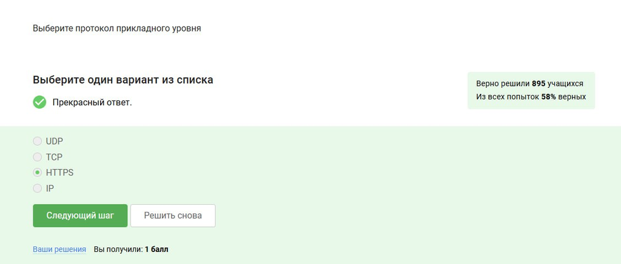

Задание 1

## Выполнение лабораторной работы

TCP работает на транспортном уровне, IP - на сетевом.

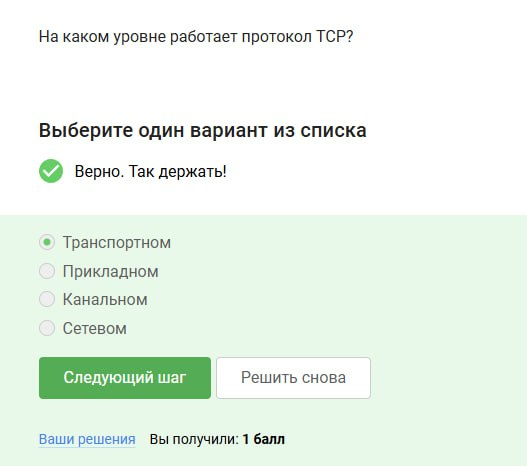

Задание 002

## Выполнение лабораторной работы

Т.к. IPv4 - набор цифр от 0 до 255, следовательно исключаем варианты, которые содержат числа больше/меньше этого набора.

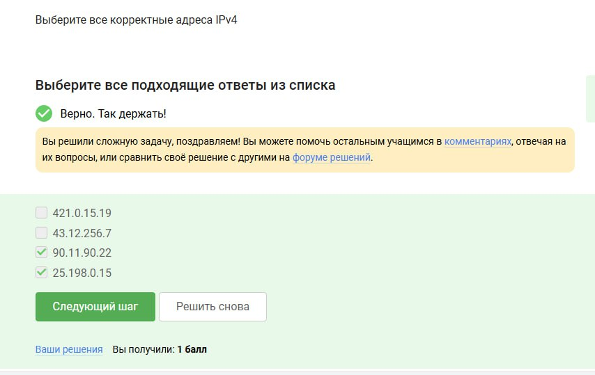

Задание 003

## Выполнение лабораторной работы

DNS сопоставляет доменное имя соответствующий ему IP.

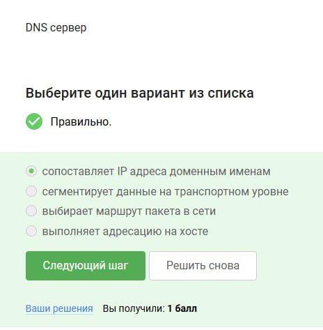

Задание 004

## Выполнение лабораторной работы

Порядок такой.

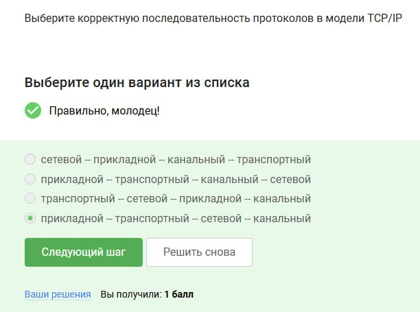

Задание 005

## Выполнение лабораторной работы

http - предоставляет в открытом виде, именно эту проблему решает https, он работает также, только в этот раз данные шифруются.

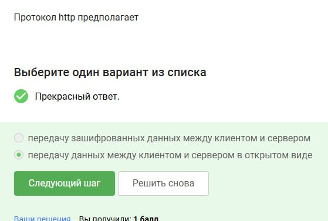

Задание 006

## Выполнение лабораторной работы

Рукопожатие и передача данных, аутентификации не входит.

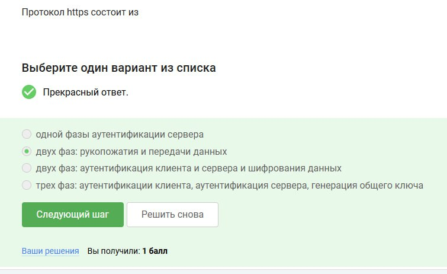

Задание 007

## Выполнение лабораторной работы

Обязательно версия протокола определяется обоими.

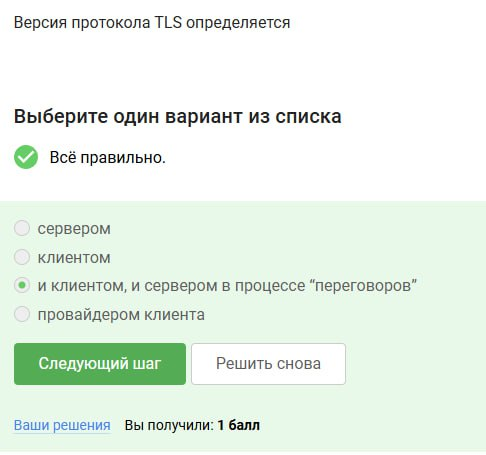

Задание 008

## Выполнение лабораторной работы

Шифрование данных не происходит в фазе рукопожатия, только после неё.

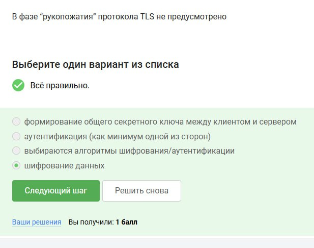

Задание 009

## Выполнение лабораторной работы

Куки не хранят пароль пользователя или его IP адрес.

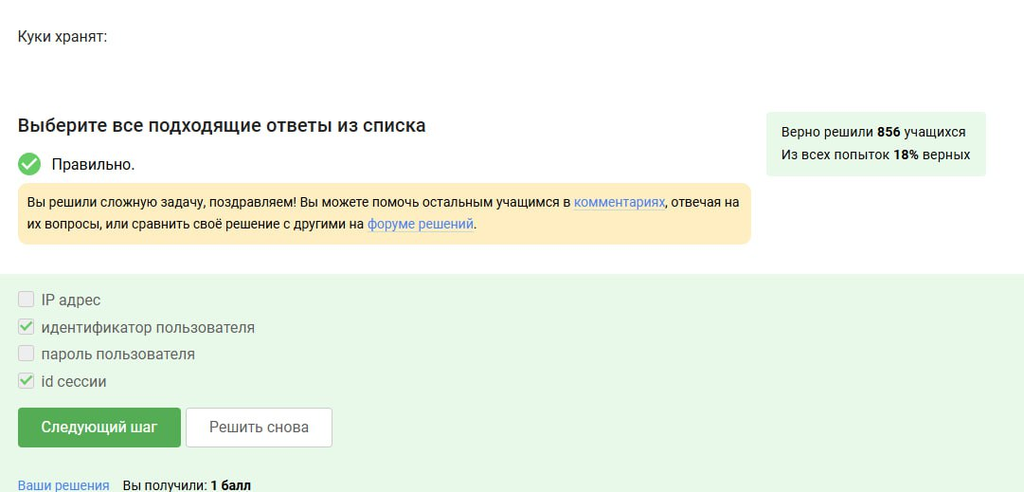

Задание 010

## Выполнение лабораторной работы

Куки не сильно влияют на безопасность, скорее упрощают работу пользователям.

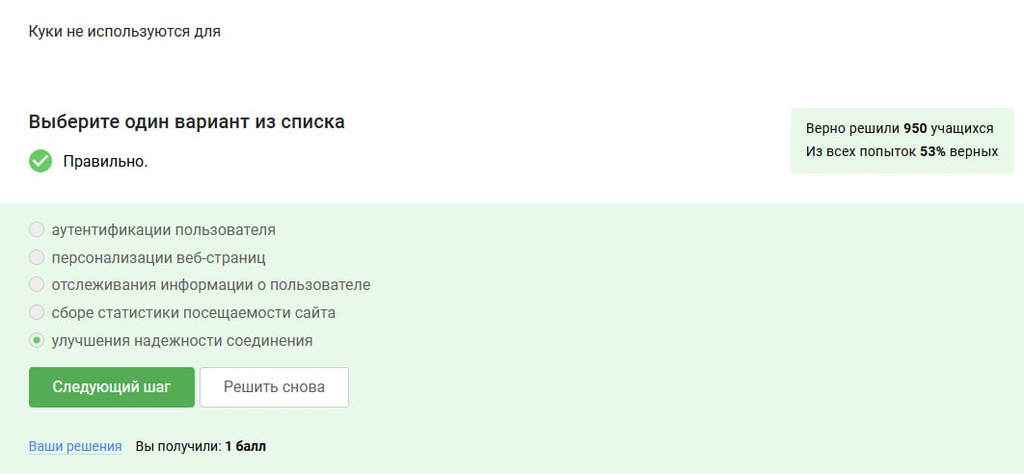

Задание 011

## Выполнение лабораторной работы

Куки генерируются сервером и отправляются клиенту, а не наоборот.

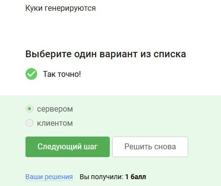

Задание 012

## Выполнение лабораторной работы

Сессионные куки исчезнут, как только мы закроем окно с веб-сайтом.

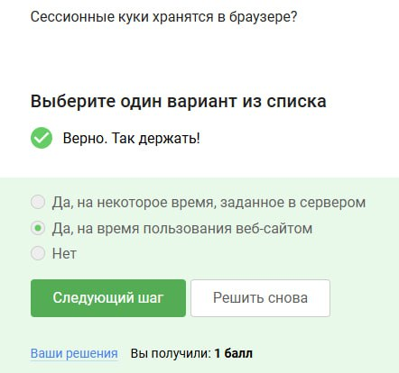

Задание 013

## Выполнение лабораторной работы

3, т.к. больше узлов анонимности не прибавляют, а при меньших узлах теряется смысл всего алгоритма маршрутизации TOR.

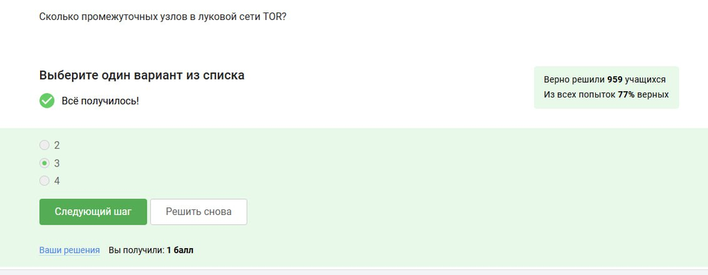

Задание 014

## Выполнение лабораторной работы

При шифровании так получается, что охранный узел и промежуточный узел не знают по итогу IP адрес получателя данных.

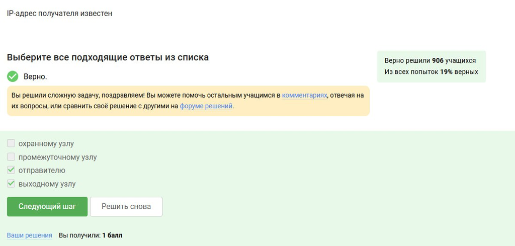

Задание 015

## Выполнение лабораторной работы

Отправитель генерирует общий секретный ключ со всеми тремя узлами.

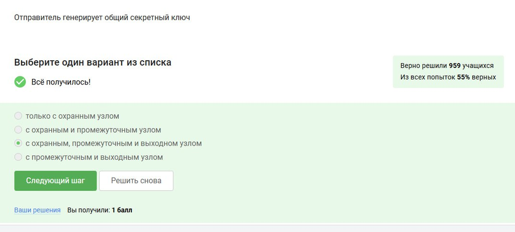

Задание 016

## Выполнение лабораторной работы

Нет, не должен, далее возвращение данных происходит как обычно.

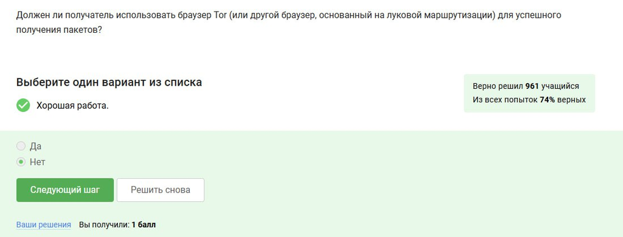

Задание 017

## Выполнение лабораторной работы

У Wi-fi нет расшифроки, вообще это была такая пометка от компании, которая проверяла поддерживает ли устройство беспроводную сеть, а так это технология беспроводной сети.

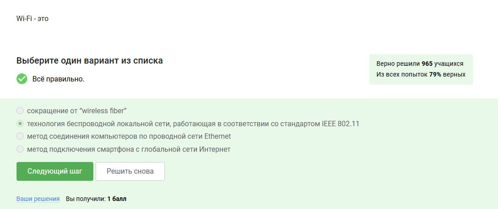

Задание 018

## Выполнение лабораторной работы

На канальном уровне, т.к. речь всё-таки идёт о физическом излучении и приёме сигнала.

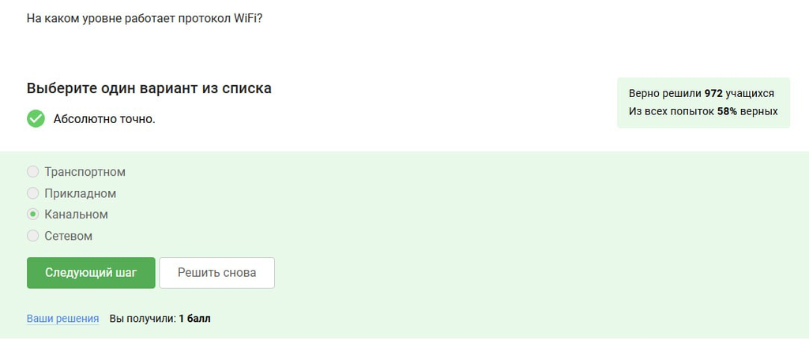

Задание 019

## Выполнение лабораторной работы

WEP самый первый, но и к сожалению, небезопасный, на данный момент самый безопасный - WPA3.

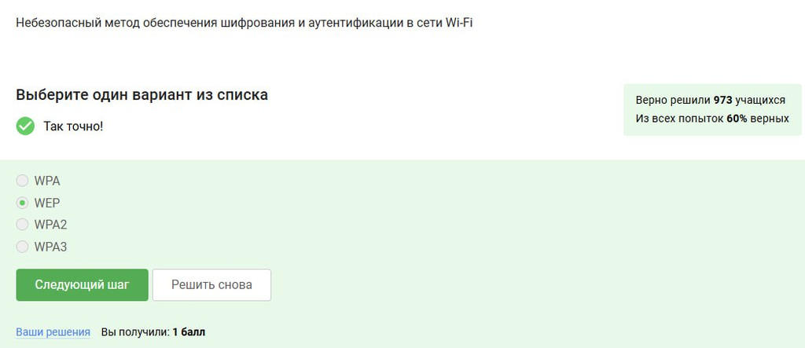

Задание 020

## Выполнение лабораторной работы

На новых версиях беспроводных сетей происходит шифрование, но перед этим обязательно аутентификация.

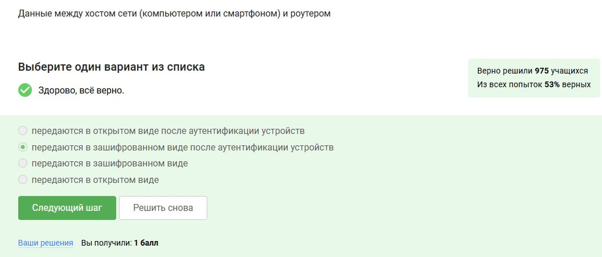

Задание 021

## Выполнение лабораторной работы

Для домашней сети - personal, для Корпоративных сетей используют Enterprise, т.к. есть база данных её пользователей. Это усиливает безопасность корпорации..

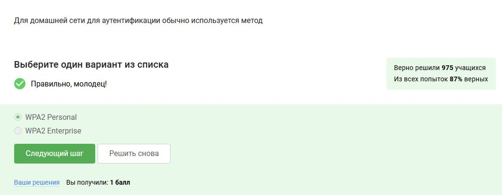

Задание 022

# Выводы

Этап 1 пройден успешно на максимальный балл.

# Список литературы

[Курс “Основы Кибербезопасности” на платформе Stepik](https://stepik.org/course/111511)